# R Notebook

```r
library(tidyverse)
library(rstan)
```

# The Model

Let $\hat{\beta_{ij}}$ be the log response ratio estimate for study j in pico group i, where
$$\begin{align}
i = 1,\dots, m ,
j = 1,\dots, n_i,
\end{align}$$
where m is the number of pico comparison groups and $n_i$ is the number of publications in each comparison group.

In our model, the log response ratio estimate $\hat{\beta_{ij}}$ is modelled by
$$\begin{align}
\hat{\beta_{ij}} = \beta_i + \gamma_{ij} + \epsilon_{ij},
\end{align}$$
where $\beta_i$ is the log response ratio for pico comparison i, $\gamma_{ij}$ is design bias in study j in pico comparison i and $\epsilon_{ij}$ is the random error in study j in pico comparison i. These components are in turn modelled by:
$$\begin{align}
\beta_j &\sim \mathcal{N}(0,\sigma_\beta^2), \\
\gamma_{ij} &\sim \mathcal{N}(0,\sigma^2(X_{ij})), \\
\epsilon_{ij} &\sim \mathcal{N}(0,\sigma_{ij}^2).
\end{align}$$
where $X_{ij}$ is a vector of design features of study j in group i, $\sigma_{ij}$ is the standard error, and
$$\begin{align}
\log \sigma^2(X_{ij}) = X_ij^T \theta .
\end{align}$$
We also assume weakly informative prior distributions:
$$\begin{align}
\sigma_\beta \sim \text{InvGamma}(1,0.02), \\
\theta_i \sim \mathcal{N}(0,1.52) .
\end{align}$$

# Constructing the model in Stan

```stan
data {
  int<lower=0> m; // number of pico comparisons
  int<lower=0> n[m]; // array of studies in each comparison
  int<lower=0> n_tot; // total number of studies in the model
  vector[n_tot] log_response; // log responses for all studies
  vector[n_tot] est_var; // estimated variance for all studies
  int<lower=0> d; // number of columns in X
  matrix[n_tot,d] X; // design matrix
}

parameters {
  vector[m] beta; // vector of log responses for the pico comparisons
  real<lower=0> sigma_beta; // standard deviation for each of the pico comparisons
  vector[d] theta; // vector of coefficients for the transformed linear relation between variance of gamma_ij and X_ij
}

model {
  int k; // this is an indexing variable for later

  sigma_beta ~ inv_gamma(1,0.02); // prior for sigma_beta

  beta ~ normal(0,sigma_beta); // prior for beta

  theta ~ normal(0,1.52); // prior for theta

  k = 1;
  for(i in 1:m){
    for(j in 1:n[i]){
      log_response[k] ~ normal(beta[i],sqrt(est_var[k] + exp(X[k,]*theta))); // relation between estiated log response and other random quantities
      k = k+1;
    }
  }
}
```

# Fitting the model to the data

The comparison group design is determined using linear optimisation techniques:

```r
load("stan_data.Rdata")
design_frame_345
```

| pico_id | rowid | Design | randomised | controlled | before_after | pub_id | group_size | contains_random.x | new_group_size | contains_random.y | optimisation_method |
| --- | --- | --- | --- | --- | --- | --- | --- | --- | --- | --- | --- |
| 1 | 169 | Before-and-after & Blocked & Controlled & Randomised & Replicated | TRUE | TRUE | TRUE | 7 | 8 | TRUE | 2 | TRUE | prioritising groups of size of 3, 4 and 5 |
| 1 | 2 | Blocked & Controlled & Randomised & Replicated | TRUE | TRUE | FALSE | 1 | 8 | TRUE | 2 | TRUE | prioritising groups of size of 3, 4 and 5 |
| 2 | 2328 | Blocked & Controlled & Randomised & Replicated | TRUE | TRUE | FALSE | 64 | 28 | TRUE | 8 | TRUE | prioritising groups of size of 3, 4 and 5 |
| 2 | 1788 | Blocked & Controlled & Randomised & Replicated | TRUE | TRUE | FALSE | 53 | 28 | TRUE | 8 | TRUE | prioritising groups of size of 3, 4 and 5 |
| 2 | 1921 | Blocked & Controlled & Randomised & Replicated | TRUE | TRUE | FALSE | 55 | 28 | TRUE | 8 | TRUE | prioritising groups of size of 3, 4 and 5 |
| 2 | 1539 | Controlled | FALSE | TRUE | FALSE | 45 | 28 | TRUE | 8 | TRUE | prioritising groups of size of 3, 4 and 5 |
| 2 | 1524 | Blocked & Controlled & Randomised & Replicated | TRUE | TRUE | FALSE | 43 | 28 | TRUE | 8 | TRUE | prioritising groups of size of 3, 4 and 5 |
| 2 | 277 | Controlled & Replicated | FALSE | TRUE | FALSE | 12 | 28 | TRUE | 8 | TRUE | prioritising groups of size of 3, 4 and 5 |
| 2 | 2321 | Blocked & Controlled & Randomised & Replicated | TRUE | TRUE | FALSE | 63 | 28 | TRUE | 8 | TRUE | prioritising groups of size of 3, 4 and 5 |
| 2 | 2225 | Blocked & Controlled & Randomised & Replicated | TRUE | TRUE | FALSE | 58 | 28 | TRUE | 8 | TRUE | prioritising groups of size of 3, 4 and 5 |

[output cut: 235 more lines]

In this next step, we are adding the relevant `log_response_ratio`, `selected_v` and `Design` information to the design frame:

```r
test_design <- design_frame_345 %>%
  select(pico_id,pub_id,rowid) #selecting the relevant information from the design frame
test_design <- merge(test_design,select(Metadataset_download_19_08_21,rowid,log_response_ratio,selected_v,Design),) #adding information on the log response rato, variance and Designt to the design frame
test_design <- test_design %>%
  arrange(pico_id) #arranging by pico_id
test_design
```

| rowid | pico_id | pub_id | log_response_ratio | selected_v | Design |
| --- | --- | --- | --- | --- | --- |
| 2 | 1 | 1 | 0.43936666 | 3.842505e-02 | Blocked & Controlled & Randomised & Replicated |
| 169 | 1 | 7 | -0.04284979 | 3.654700e-04 | Before-and-after & Blocked & Controlled & Randomised & Replicated |
| 277 | 2 | 12 | 0.00995033 | 1.942954e-01 | Controlled & Replicated |
| 1524 | 2 | 43 | 0.57097955 | 1.942954e-01 | Blocked & Controlled & Randomised & Replicated |
| 1539 | 2 | 45 | 0.66782937 | 1.942954e-01 | Controlled |
| 1788 | 2 | 53 | 0.59883650 | 1.942954e-01 | Blocked & Controlled & Randomised & Replicated |
| 1921 | 2 | 55 | 0.47623418 | 1.942954e-01 | Blocked & Controlled & Randomised & Replicated |
| 2225 | 2 | 58 | 0.33647224 | 1.942954e-01 | Blocked & Controlled & Randomised & Replicated |
| 2321 | 2 | 63 | 0.45107562 | 1.942954e-01 | Blocked & Controlled & Randomised & Replicated |
| 2328 | 2 | 64 | 0.76080583 | 1.942954e-01 | Blocked & Controlled & Randomised & Replicated |

[output cut: 235 more lines]

Using the `test_design` we can now record data for the Stan model:

```r
stan_data <- list(
  m = length(unique(test_design$pico_id)), #since m is the number of pico comparisons

  n = as.array((test_design %>%
                  group_by(pico_id) %>%
                  summarise(num_publications = n_distinct(pub_id)))$num_publications), #this is the number of distinct publications in each group, and is inputted as an array as this is the variable type of n in the model

  n_tot = sum(as.array((test_design %>%
                      group_by(pico_id) %>%
                      summarise(num_publications = n_distinct(pub_id)))$num_publications)), #this is the total number of publications in each group

  log_response = as.vector(test_design$log_response_ratio), #this is the vector of log response ratios

  est_var = as.vector(test_design$selected_v), #this is the vector of variances for the log response ratio

  d = 5, #specifies number of comparisons we are interested in (including the intercept)

  #Design matrix:
  X = as.matrix(test_design %>%
                  select(Design) %>%
                  mutate(randomised = str_detect(Design,"(R|r)andom"),
                         controlled = str_detect(Design,"(C|c)ontrol"),
                         before_after = str_detect(Design,"(B|b)efore"),
                         BACI = controlled & before_after) %>% #creating columns containing boulean values indicating presence of design features of interest
                  select(-Design) %>% #removing un-needed columns
                  mutate(across(.cols = everything(),~if_else(.,1,0))) %>% #converting the bouleans into binary variables
                  mutate(intercept = 1) %>% #adding an intercept column
                  select(intercept,randomised,controlled,before_after,BACI))
) #rearranging for desired order of columns
```

Now we fit the Stan model to the data:

```r
fit <- sampling(model,data = stan_data)
fit
```

```
## Inference for Stan model: 2344ca100ce9715b6356f7bef4d28402.
## 4 chains, each with iter=2000; warmup=1000; thin=1;
## post-warmup draws per chain=1000, total post-warmup draws=4000.
##
##               mean se_mean   sd    2.5%     25%     50%     75%   97.5% n_eff
## beta[1]       0.23    0.00 0.28   -0.31    0.04    0.22    0.40    0.78  9361
## beta[2]       0.48    0.00 0.20    0.09    0.35    0.48    0.62    0.87  8409
## beta[3]      -0.08    0.00 0.23   -0.54   -0.24   -0.08    0.07    0.37 10395
## beta[4]      -0.11    0.00 0.07   -0.25   -0.16   -0.11   -0.07    0.02  7326
## beta[5]       0.48    0.00 0.27   -0.05    0.30    0.48    0.67    1.00  8337
## beta[6]      -0.15    0.00 0.22   -0.59   -0.30   -0.15   -0.01    0.27 10475
## beta[7]      -0.29    0.00 0.29   -0.86   -0.48   -0.29   -0.10    0.27  8107
## beta[8]      -0.20    0.00 0.24   -0.67   -0.36   -0.20   -0.04    0.25  9701
## beta[9]      -0.19    0.00 0.26   -0.72   -0.36   -0.19   -0.03    0.32  8333
## beta[10]     -0.22    0.00 0.30   -0.80   -0.42   -0.22   -0.02    0.36  9655
## beta[11]     -0.23    0.00 0.19   -0.61   -0.35   -0.23   -0.10    0.14  9934
## beta[12]     -0.31    0.00 0.22   -0.74   -0.46   -0.32   -0.17    0.16  8383
## beta[13]     -0.01    0.00 0.26   -0.52   -0.17   -0.01    0.16    0.50  8481
## beta[14]     -0.02    0.00 0.28   -0.55   -0.20   -0.02    0.16    0.52  8857
## beta[15]      0.04    0.00 0.20   -0.36   -0.09    0.04    0.17    0.43 10278
## beta[16]      0.05    0.00 0.27   -0.49   -0.13    0.04    0.23    0.59  9132
## beta[17]      0.02    0.00 0.26   -0.50   -0.15    0.02    0.20    0.53  8730
## beta[18]     -0.24    0.00 0.22   -0.69   -0.38   -0.24   -0.10    0.19  8892
## beta[19]     -0.47    0.00 0.28   -1.04   -0.66   -0.47   -0.28    0.09  8825
## beta[20]      0.49    0.00 0.32   -0.14    0.27    0.49    0.70    1.11  9927
## beta[21]      0.01    0.00 0.26   -0.51   -0.16    0.01    0.17    0.52  8788
## beta[22]      0.11    0.00 0.33   -0.55   -0.11    0.10    0.33    0.75  8342
## beta[23]     -0.42    0.00 0.21   -0.84   -0.55   -0.41   -0.28   -0.02  8944
## beta[24]     -0.53    0.00 0.35   -1.21   -0.77   -0.53   -0.30    0.17  8720
## beta[25]     -0.81    0.00 0.30   -1.38   -1.00   -0.82   -0.61   -0.20  8516
## beta[26]      0.10    0.00 0.27   -0.44   -0.08    0.10    0.28    0.63 11036
## beta[27]     -0.42    0.01 0.49   -1.35   -0.74   -0.43   -0.11    0.54  7968
## beta[28]     -0.56    0.01 0.71   -1.95   -1.04   -0.55   -0.08    0.82  8698
## beta[29]     -0.22    0.01 0.52   -1.25   -0.56   -0.22    0.12    0.78  8186
## beta[30]      0.46    0.00 0.39   -0.31    0.20    0.46    0.73    1.22  8648
## beta[31]      0.28    0.00 0.20   -0.11    0.15    0.28    0.41    0.68  8541
## beta[32]      0.57    0.00 0.36   -0.17    0.34    0.58    0.81    1.25  6611
## beta[33]     -1.03    0.01 0.43   -1.87   -1.32   -1.02   -0.73   -0.18  7018
## beta[34]     -0.18    0.00 0.20   -0.57   -0.31   -0.18   -0.05    0.21  9684
## beta[35]      0.84    0.00 0.31    0.23    0.63    0.84    1.05    1.44  8044
```

[output cut: 102 more lines]

```
## beta[64]      1
## beta[65]      1
## beta[66]      1
## sigma_beta    1
## theta[1]      1
## theta[2]      1
## theta[3]      1
## theta[4]      1
## theta[5]      1
## lp__          1
##
## Samples were drawn using NUTS(diag_e) at Wed Sep 22 12:14:24 2021.
## For each parameter, n_eff is a crude measure of effective sample size,
## and Rhat is the potential scale reduction factor on split chains (at
## convergence, Rhat=1).
```

The chains appear to converge:

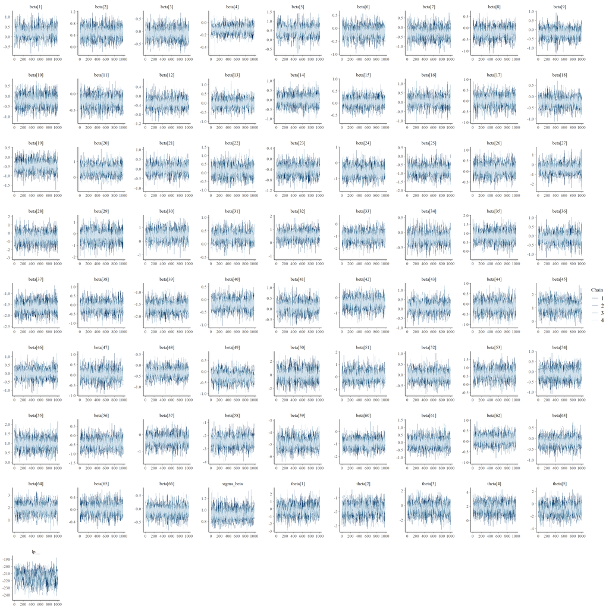

```r
library(bayesplot)
fit %>%
  mcmc_trace()
```